# MGT6203 Project - Trend & Seasonality Analysis

Majed AlOtaibi

7/15/2023

## Background

Road traffic crashes are a leading cause of death in many countries, especially those with people living in high-population density environments. In this project, due to data availability issues, we will be focusing on the city of New York City in the United States

## Data Description & Pre-processing

This work is a compiled result of cleaning and using the following data sets: 1. Crashes dataset. 2. Vehicles dataset 3. Persons dataset 4. New York city spatial dataset 5. New York city weather dataset

The cleaned dataset has the following columns:

1. **COLLISION_ID** Auto generated ID for the crash
2. **CRASH.DATETIME** Crash Date and Time
3. **TIME_OF_DAY** Time of Day (morning, afternoon, or evening)
4. **STATE** All the data set records in NY
5. **PO_NAME** Postal Name (48 unique values in NY)
6. **ZIPCODE** ZIP Code (193 unique values in NY)
7. **LATITUDE** Latitude of the crash
8. **LONGITUDE** Longitude of the crash
9. **NUMBER.OF.PERSONS.INJURED** Number of Persons Injured in the crash
10. **NUMBER.OF.PERSONS.KILLED** Number of Persons Killed in the crash
11. **NUMBER.OF.PEDESTRIANS.INJURED** Number of Pedestrians Injured in the crash
12. **NUMBER.OF.PEDESTRIANS.KILLED** Number of Pedestrians Killed in the crash
13. **NUMBER.OF.CYCLIST.INJURED** Number of Cyclist Injured in the crash
14. **NUMBER.OF.CYCLIST.KILLED** Number of Cyclist Killed in the crash
15. **NUMBER.OF.MOTORIST.INJURED** Number of Motorist Injured in the crash
16. **NUMBER.OF.MOTORIST.KILLED** Number of Motorist Killed in the crash
17. **VEHICLE.CATEGORY** 17 vehicle category
18. **POPULATION** Population of the crash area
19. **AREA** Area size where the crash happened
20. **COUNTY** County where the crash happened in NYC (5 Unique values)

In this part of the analysis, will focus on the crash date and try to find any trend or seasonal pattern using the following data columns: 1. **NUMBER.OF.PERSONS.INJURED** Number of Persons Injured in the crash 2. **NUMBER.OF.PERSONS.KILLED** Number of Persons Killed in the crash 3. **NUMBER.OF.PEDESTRIANS.INJURED** Number of Pedestrians Injured in the crash 4. **NUMBER.OF.PEDESTRIANS.KILLED** Number of Pedestrians Killed in the crash 5. **NUMBER.OF.CYCLIST.INJURED** Number of Cyclist Injured in the crash 6. **NUMBER.OF.CYCLIST.KILLED** Number of Cyclist Killed in the crash 7. **NUMBER.OF.MOTORIST.INJURED** Number of Motorist Injured in the crash 8. **NUMBER.OF.MOTORIST.KILLED** Number of Motorist Killed in the crash

```r
# Clear variables in memory
rm(list=ls())

# Load required libraries
library(dplyr)
```

```r
library(ggplot2)
library(lubridate)
# Reading the data
data <- read.csv("~/Majed AlOtaibi/University/Master/Courses/MGT6203/Project/Data/crashes-cleaned.csv", header=TRUE)
```

## Crash Date Varibale processing

```r
data$CRASH_DATE <- as.Date(strptime(as.character(data$CRASH.DATETIME), "%Y-%m-%d"))
# Remove unneeded columns
data$COLLISION_ID <- NULL
data$STATE <- NULL
data$CRASH.DATETIME <- NULL
data$LATITUDE <- NULL
data$LONGITUDE <- NULL
data$TIME_OF_DAY <- NULL
data$PO_NAME <- NULL
data$ZIPCODE <- NULL
data$VEHICLE.CATEGORY <- NULL
data$COUNTY <- NULL
data$POPULATION <- NULL
data$AREA <- NULL

head(data)
```

```
##   NUMBER.OF.PERSONS.INJURED NUMBER.OF.PERSONS.KILLED
## 1                         0                        0
## 2                         0                        0
## 3                         0                        0
## 4                         0                        0
## 5                         0                        0
## 6                         0                        0
##   NUMBER.OF.PEDESTRIANS.INJURED NUMBER.OF.PEDESTRIANS.KILLED
## 1                             0                            0
## 2                             0                            0
## 3                             0                            0
## 4                             0                            0
## 5                             0                            0
## 6                             0                            0
##   NUMBER.OF.CYCLIST.INJURED NUMBER.OF.CYCLIST.KILLED NUMBER.OF.MOTORIST.INJURED
## 1                         0                        0                          0
## 2                         0                        0                          0
## 3                         0                        0                          0
## 4                         0                        0                          0
## 5                         0                        0                          0
## 6                         0                        0                          0
##   NUMBER.OF.MOTORIST.KILLED CRASH_DATE
## 1                         0 2012-07-01
## 2                         0 2012-07-01
## 3                         0 2012-07-01
## 4                         0 2012-07-01
## 5                         0 2012-07-01
## 6                         0 2012-07-01
```

# Prepare the total monthly numbers grouped by Year

```r
monthly_data <- data %>%
    filter(CRASH_DATE >= "2013-01-01" & CRASH_DATE <= "2022-12-31") %>%
  group_by(month = factor(as.character(month(CRASH_DATE, label = T, locale = Sys.setlocale("LC_TIME", "English"))),
                            levels = c('Jan','Feb','Mar','Apr','May','Jun','Jul','Aug','Sep','Oct','Nov','Dec')),
           year = year(CRASH_DATE)) %>%
  summarise(monthly_per_injured=sum(NUMBER.OF.PERSONS.INJURED, na.rm=TRUE),
            monthly_per_killed=sum(NUMBER.OF.PERSONS.KILLED, na.rm=TRUE),
            monthly_ped_injured=sum(NUMBER.OF.PEDESTRIANS.INJURED, na.rm=TRUE),
            monthly_ped_killed=sum(NUMBER.OF.PEDESTRIANS.KILLED, na.rm=TRUE),
            monthly_cyc_injured=sum(NUMBER.OF.CYCLIST.INJURED, na.rm=TRUE),
            monthly_cyc_killed=sum(NUMBER.OF.CYCLIST.KILLED, na.rm=TRUE),
            monthly_mot_injured=sum(NUMBER.OF.MOTORIST.INJURED, na.rm=TRUE),
            monthly_mot_killed=sum(NUMBER.OF.MOTORIST.KILLED, na.rm=TRUE),.groups = "keep")

head(monthly_data)
```

```
## # A tibble: 6 x 10
## # Groups:   month, year [6]
##   month  year monthly_per_injured monthly_per_killed monthly_ped_injured
##   <fct> <dbl>               <int>              <int>               <int>
## 1 Jan    2013                3447                 29                 999
## 2 Jan    2014                3307                 21                 978
## 3 Jan    2015                2966                 14                 810
## 4 Jan    2016                3146                 15                 820
## 5 Jan    2017                4197                 18                1082
## 6 Jan    2018                4203                 12                 991
## # i 5 more variables: monthly_ped_killed <int>, monthly_cyc_injured <int>,
## #   monthly_cyc_killed <int>, monthly_mot_injured <int>,
## #   monthly_mot_killed <int>
```

# Trend & Seasonality analysis

## 1. Monthly persons injured

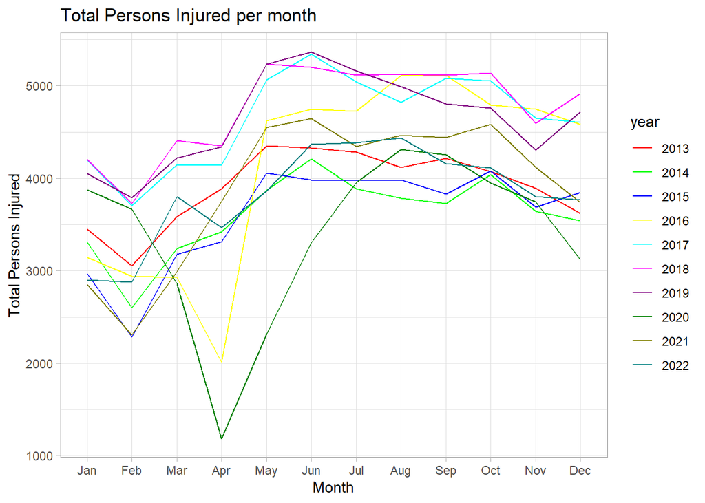

```r
ggplot(monthly_data, aes(x=month, y=monthly_per_injured, color=as.factor(year), group = year)) +
geom_line()   +
  scale_color_manual(values=c("#FF0000", "#00FF00", "#0000FF","#FFFF00","#00FFFF","#FF00FF","#800080","#008000","#808000","#008080"))+
  theme(legend.position="top")+
ylab('Total Persons Injured')   +
xlab('Month') +
theme_light() +
labs(title="Total Persons Injured per month" ,color = "year")
```

The total number of persons injured in a crash in beginning of the year (Jan-April) is lower than later months in the year.

## 2. Monthly persons killed

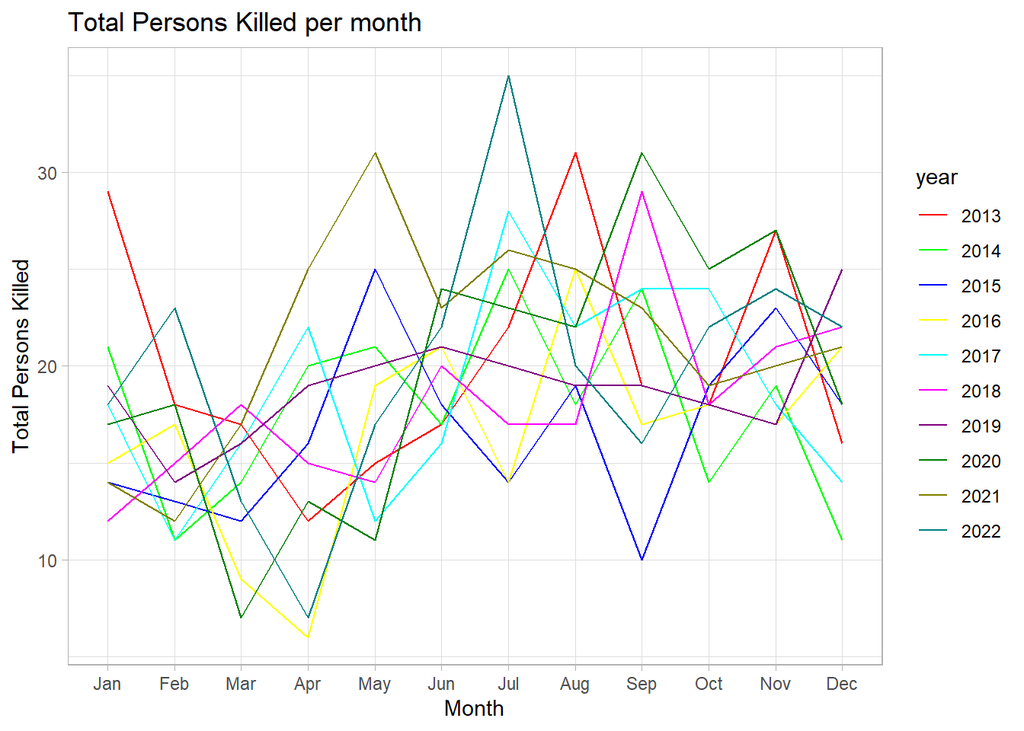

```r
ggplot(monthly_data, aes(x=month, y=monthly_per_killed, color=as.factor(year), group = year)) +
geom_line()   +
  scale_color_manual(values=c("#FF0000", "#00FF00", "#0000FF","#FFFF00","#00FFFF","#FF00FF","#800080","#008000","#808000","#008080"))+
  theme(legend.position="top")+
ylab('Total Persons Killed')   +
xlab('Month') +
theme_light() +
labs(title="Total Persons Killed per month" ,color = "year")
```

There is no clear pattern in monthly total number of Persons death in crash.

## 3. Monthly Pedestrians injured

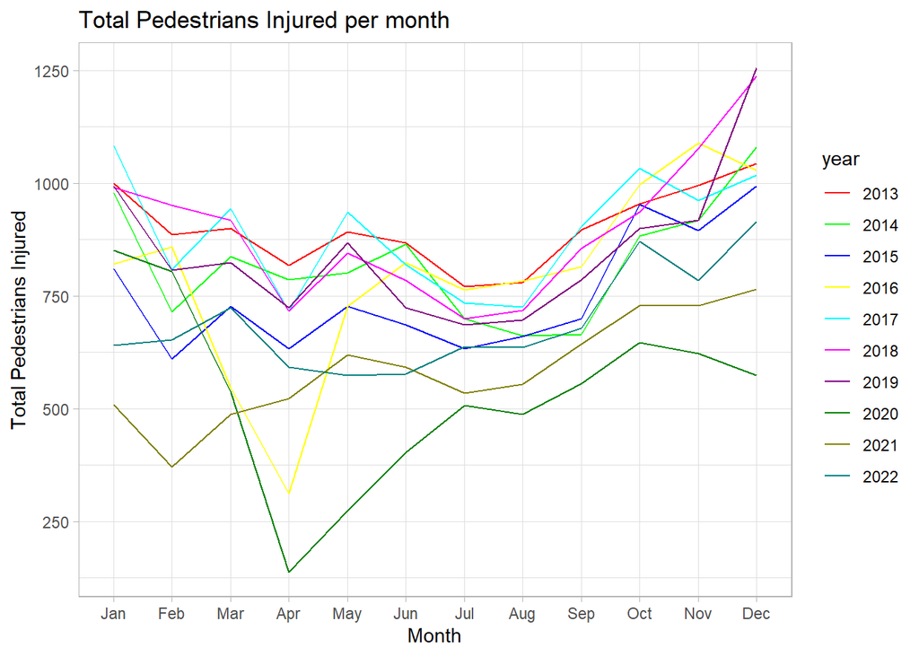

```r
ggplot(monthly_data, aes(x=month, y=monthly_ped_injured, color=as.factor(year), group = year)) +
geom_line()   +
  scale_color_manual(values=c("#FF0000", "#00FF00", "#0000FF","#FFFF00","#00FFFF","#FF00FF","#800080","#008000","#808000","#008080"))+
  theme(legend.position="top")+
ylab('Total Pedestrians Injured')   +
xlab('Month') +
theme_light() +
labs(title="Total Pedestrians Injured per month" ,color = "year")
```

The total number of Pedestrians injured in a crash in mid of the year (April-Aug) is lower than beginning and end in the year.

## 4. Monthly Pedestrians killed

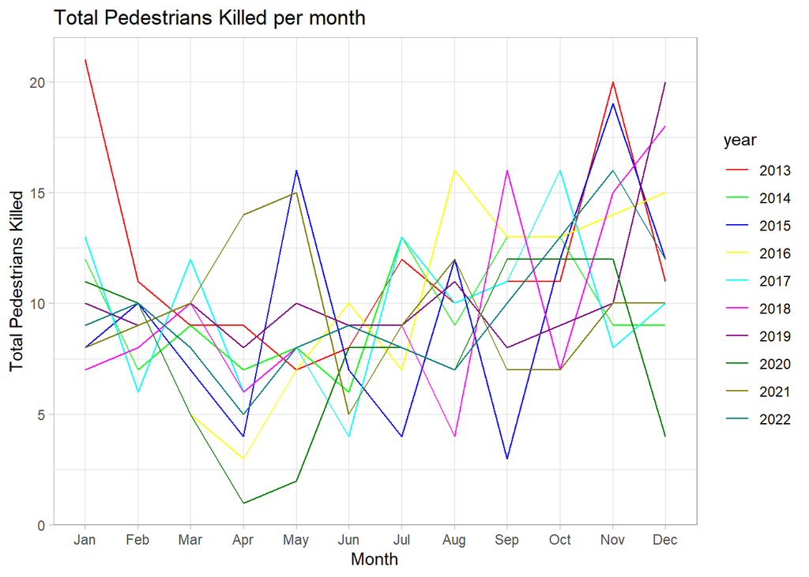

```r
# Plot monthly Pedestrians killed
ggplot(monthly_data, aes(x=month, y=monthly_ped_killed, color=as.factor(year), group = year)) +
geom_line()   +
  scale_color_manual(values=c("#FF0000", "#00FF00", "#0000FF","#FFFF00","#00FFFF","#FF00FF","#800080","#008000","#808000","#008080"))+
  theme(legend.position="top")+
ylab('Total Pedestrians Killed')   +
xlab('Month') +
theme_light() +
labs(title="Total Pedestrians Killed per month" ,color = "year")
```

There is no clear pattern in monthly total number of Pedestrians death in crash.

## 5. Monthly Cyclist injured

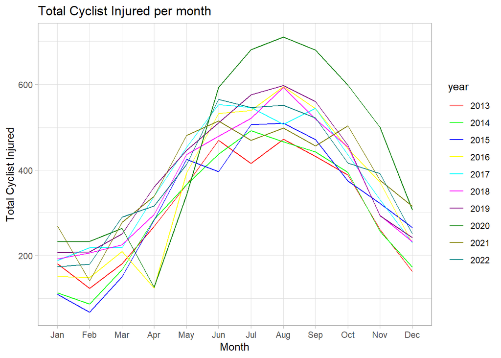

```r
# Plot monthly Cyclist injured
ggplot(monthly_data, aes(x=month, y=monthly_cyc_injured, color=as.factor(year), group = year)) +
geom_line()   +
  scale_color_manual(values=c("#FF0000", "#00FF00", "#0000FF","#FFFF00","#00FFFF","#FF00FF","#800080","#008000","#808000","#008080"))+
  theme(legend.position="top")+
ylab('Total Cyclist Injured')   +
xlab('Month') +
theme_light() +
labs(title="Total Cyclist Injured per month" ,color = "year")
```

Simillary to the monthly Total Persons Injured, The total number of Cyclist injured in a crash in beginning and end of the year (Jan-April) and (Nov-Dec) is lower than mid year months.

## 6. Monthly Cyclist killed

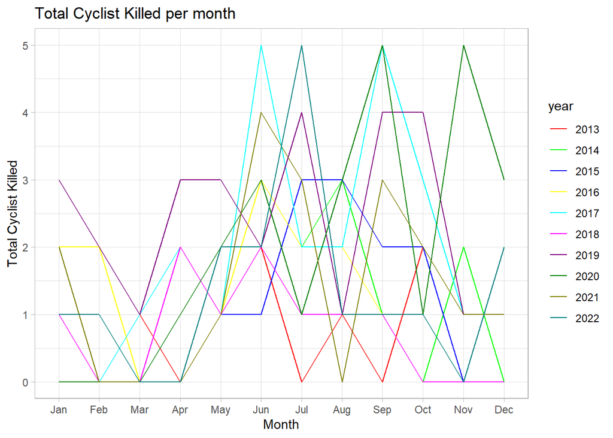

```r
# Plot monthly Cyclist killed
ggplot(monthly_data, aes(x=month, y=monthly_cyc_killed, color=as.factor(year), group = year)) +
geom_line()   +
  scale_color_manual(values=c("#FF0000", "#00FF00", "#0000FF","#FFFF00","#00FFFF","#FF00FF","#800080","#008000","#808000","#008080"))+
  theme(legend.position="top")+
ylab('Total Cyclist Killed')   +
xlab('Month') +
theme_light() +
labs(title="Total Cyclist Killed per month" ,color = "year")
```

The total number of Cyclist killed is kind of following The total number of Cyclist injured where it’s high towards the mid of the year.

## 7. Monthly Motorist injured

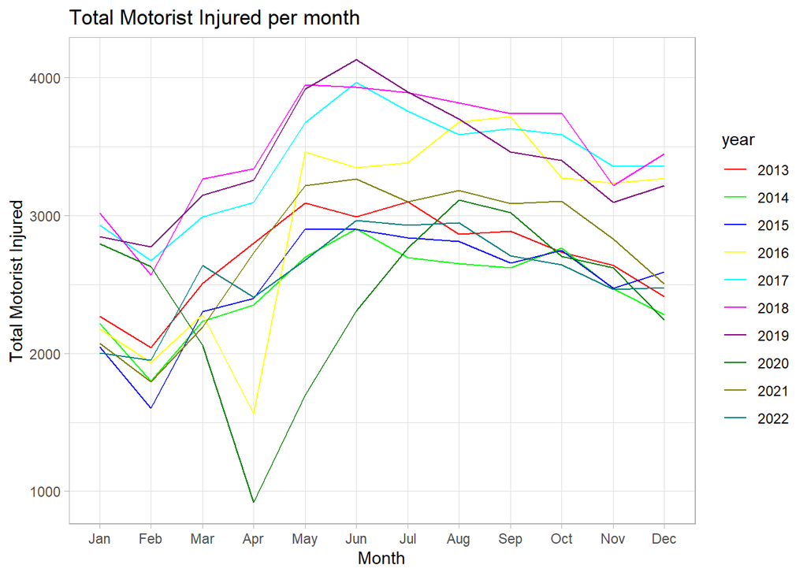

```r
# Plot monthly Motorist injured
ggplot(monthly_data, aes(x=month, y=monthly_mot_injured, color=as.factor(year), group = year)) +
geom_line()   +
  scale_color_manual(values=c("#FF0000", "#00FF00", "#0000FF","#FFFF00","#00FFFF","#FF00FF","#800080","#008000","#808000","#008080"))+
  theme(legend.position="top")+
ylab('Total Motorist Injured')   +
xlab('Month') +
theme_light() +
labs(title="Total Motorist Injured per month" ,color = "year")
```

The total number of Motorist injured in a crash in beginning of the year (Jan-April) is lower than later months in the year.

## 8. Monthly Motorist killed

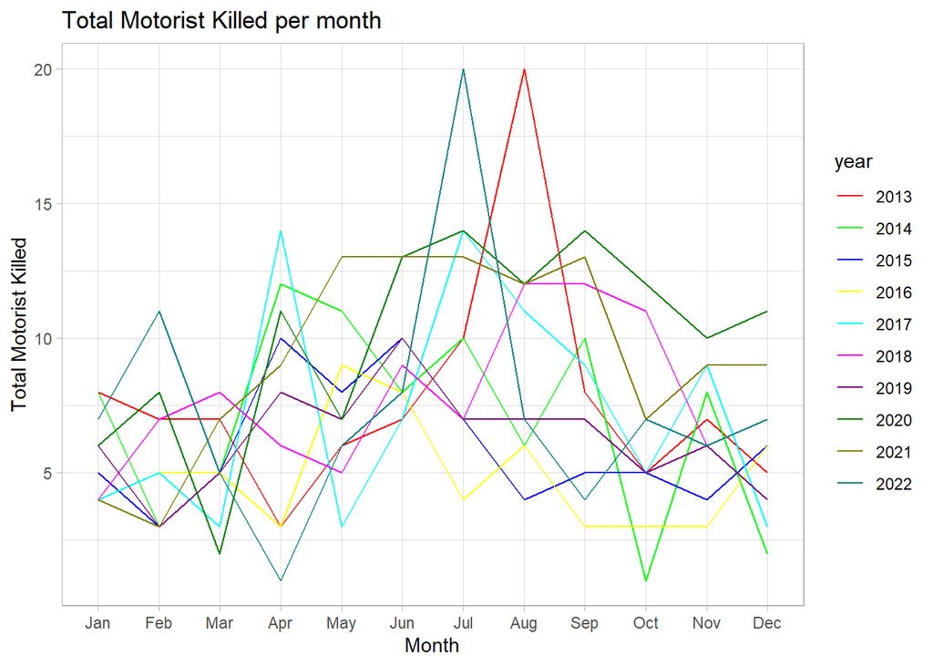

```r
# Plot monthly Motorist killed
ggplot(monthly_data, aes(x=month, y=monthly_mot_killed, color=as.factor(year), group = year)) +
geom_line()   +
  scale_color_manual(values=c("#FF0000", "#00FF00", "#0000FF","#FFFF00","#00FFFF","#FF00FF","#800080","#008000","#808000","#008080"))+
  theme(legend.position="top")+
ylab('Total Motorist Killed')   +
xlab('Month') +
theme_light() +
labs(title="Total Motorist Killed per month" ,color = "year")
```